# Norm_Imputation_strategy_selection

## 3. Correlation of normalized data (no imputation)

```r
#ΔCt (sample) = Ct(reference gene) - Ct(gene of interest)

calculate_delta_ct <- function(df, HKG) {
  # Extract the column of the housekeeping gene
  reference_gene <- df[[HKG]]
  Mouse_ID <- df$Mouse_ID
  g <- df[, colnames(df) %in% Genes_v]

  delta_ct <- sapply(g, function(gene) reference_gene - gene)
  delta_ct <- as.data.frame(cbind(Mouse_ID, delta_ct))
  return(delta_ct)
}

# more positive = higher expression

# Use the function
norm_field <- calculate_delta_ct(field, "GAPDH")

norm_lab <- calculate_delta_ct(lab, "PPIB")

norm_g <- rbind(norm_field, norm_lab)

hm_norm <- hm %>%
    dplyr::select(-all_of(Genes_v)) %>%
    left_join(norm_g, by = "Mouse_ID")

rm(result, norm_g)
```

### Correlations normalised genes (no imputation)

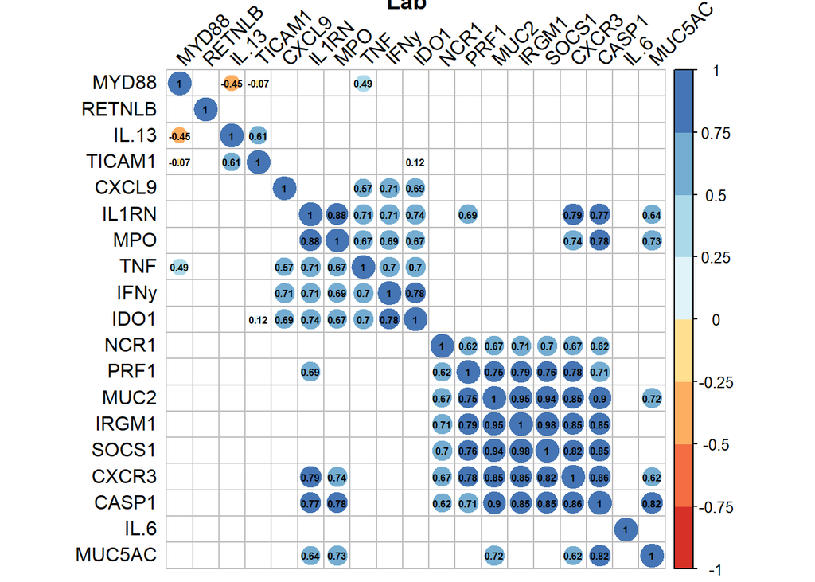

```r
lab <- hm_norm%>%
    filter(origin== "Lab")

gene_correlation <- sapply(lab[,Genes_v], as.numeric)

# draw correlation between the genes
gene_correlation <- as.matrix(cor(gene_correlation,
                                  use="pairwise.complete.obs"))

# matrix of the p-value of the correlatio
p.mat <- cor.mtest(gene_correlation)

corrplot(gene_correlation,
         method = "circle",  #method of the plot, "color" would show colour gradient
         tl.col = "black", tl.srt=45, #colour of labels and rotation
         col = brewer.pal(n = 8, name ="RdYlBu"), #colour of matrix
         order="hclust", #hclust reordering
         p.mat = p.mat, sig.level = 0.01, insig = "blank",
         addCoef.col = 'black',
         number.cex=0.5,
         title = "Lab")
```

```r
  #Add significance level to the correlogram
#remove the values that are insignificant
```

## 4. Correlation of 1st normalized and sequentially imputed gene expression data

```r
hm_genes <- hm_norm[,c("Mouse_ID", Genes_v)]


genes <- hm_genes[, -1]

#init <- mice(genes, maxit = 0)
```

Error in edit.setup(data, setup, …) : `mice` detected constant and/or collinear variables. No predictors were left after their removal.

The treshold for colinearity in the package “MICE” is set to a max correlation of 0.99 by default.

The normalised gene expression values present a maximum correlation of

```r
max(gene_correlation[gene_correlation < 1], na.rm = TRUE)
```

```
## [1] 0.9843948
```

between genes.

I can’t run mice as genes become “too” correlated.

I can’t get this to work: https://github.com/amices/mice/issues/278

## 5. Corrrelation of 1st imputed and sequentially normalized gene expression data

```r
field <- hm_imp %>%
    dplyr::filter(origin == "Field")

lab <- hm_imp %>%
    dplyr::filter(origin == "Lab")

#ΔCt (sample) = Ct(reference gene) - Ct(gene of interest)

# more positive = higher expression

# Use the function
norm_field <- calculate_delta_ct(field, "GAPDH")

norm_lab <- calculate_delta_ct(lab, "PPIB")

norm_g <- rbind(norm_field, norm_lab)

hm_norm <- hm %>%
    dplyr::select(-all_of(Genes_v)) %>%
    left_join(norm_g, by = "Mouse_ID")
```

[figure not shown]

```r
lab <- hm_norm%>%
    filter(origin== "Lab")

gene_correlation <- sapply(lab[,Genes_v], as.numeric)

# draw correlation between the genes
gene_correlation <- as.matrix(cor(gene_correlation,
                                  use="pairwise.complete.obs"))

# matrix of the p-value of the correlatio
p.mat <- cor.mtest(gene_correlation)

corrplot(gene_correlation,
         method = "circle",  #method of the plot, "color" would show colour gradient
         tl.col = "black", tl.srt=45, #colour of labels and rotation
         col = brewer.pal(n = 8, name ="RdYlBu"), #colour of matrix
         order="hclust", #hclust reordering
         p.mat = p.mat, sig.level = 0.01, insig = "blank",
         addCoef.col = 'black',
         number.cex=0.5,
         title = "Lab")
```

```r
  #Add significance level to the correlogram
#remove the values that are insignificant
```